> **Tip**: Welcome to the Investigate a Dataset project! You will find tips in quoted sections like this to help organize your approach to your investigation. Before submitting your project, it will be a good idea to go back through your report and remove these sections to make the presentation of your work as tidy as possible. First things first, you might want to double-click this Markdown cell and change the title so that it reflects your dataset and investigation.

# Project: Investigate a Dataset

- Introduction
- Data Wrangling
- Exploratory Data Analysis
- Conclusions

## Introduction

> **Tip**: In this section of the report, provide a brief introduction to the dataset you've selected for analysis. At the end of this section, describe the questions that you plan on exploring over the course of the report. Try to build your report around the analysis of at least one dependent variable and three independent variables.

> If you haven't yet selected and downloaded your data, make sure you do that first before coming back here. If you're not sure what questions to ask right now, then make sure you familiarize yourself with the variables and the dataset context for ideas of what to explore.

```python
import numpy as np
import pandas as pd
import matplotlib.pyplot as plt
import seaborn as sns
from pandas import Series, DataFrame
import csv
%matplotlib inline
```

## Data Wrangling

> *Load data - general info - overview - Identify problems

### General Properties

```python
# Load moveis data
df = pd.read_csv('tmdb-movies.csv')
df.head(3)
```

|  | id | imdb_id | popularity | budget | revenue | original_title | cast | homepage | director | tagline | ... | overview | runtime | genres | production_companies | release_date | vote_count | vote_average | release_year | budget_adj | revenue_adj |
| --- | --- | --- | --- | --- | --- | --- | --- | --- | --- | --- | --- | --- | --- | --- | --- | --- | --- | --- | --- | --- | --- |
| 0 | 135397 | tt0369610 | 32.985763 | 150000000 | 1513528810 | Jurassic World | Chris Pratt\|Bryce Dallas Howard\|Irrfan Khan\|Vi... | http://www.jurassicworld.com/ | Colin Trevorrow | The park is open. | ... | Twenty-two years after the events of Jurassic ... | 124 | Action\|Adventure\|Science Fiction\|Thriller | Universal Studios\|Amblin Entertainment\|Legenda... | 6/9/15 | 5562 | 6.5 | 2015 | 1.379999e+08 | 1.392446e+09 |
| 1 | 76341 | tt1392190 | 28.419936 | 150000000 | 378436354 | Mad Max: Fury Road | Tom Hardy\|Charlize Theron\|Hugh Keays-Byrne\|Nic... | http://www.madmaxmovie.com/ | George Miller | What a Lovely Day. | ... | An apocalyptic story set in the furthest reach... | 120 | Action\|Adventure\|Science Fiction\|Thriller | Village Roadshow Pictures\|Kennedy Miller Produ... | 5/13/15 | 6185 | 7.1 | 2015 | 1.379999e+08 | 3.481613e+08 |
| 2 | 262500 | tt2908446 | 13.112507 | 110000000 | 295238201 | Insurgent | Shailene Woodley\|Theo James\|Kate Winslet\|Ansel... | http://www.thedivergentseries.movie/#insurgent | Robert Schwentke | One Choice Can Destroy You | ... | Beatrice Prior must confront her inner demons ... | 119 | Adventure\|Science Fiction\|Thriller | Summit Entertainment\|Mandeville Films\|Red Wago... | 3/18/15 | 2480 | 6.3 | 2015 | 1.012000e+08 | 2.716190e+08 |

3 rows × 21 columns

```python
df.sample(3)
```

|  | id | imdb_id | popularity | budget | revenue | original_title | cast | homepage | director | tagline | ... | overview | runtime | genres | production_companies | release_date | vote_count | vote_average | release_year | budget_adj | revenue_adj |
| --- | --- | --- | --- | --- | --- | --- | --- | --- | --- | --- | --- | --- | --- | --- | --- | --- | --- | --- | --- | --- | --- |
| 264 | 317952 | tt4126304 | 0.471393 | 0 | 0 | Cartel Land | Robert Hetrick\|José Manuel Mireles Valverde | NaN | Matthew Heineman | NaN | ... | In the Mexican state of Michoacán, Dr. Jose M... | 100 | Drama\|Documentary | The Documentary Group\|Our Time Projects | 7/3/15 | 112 | 7.5 | 2015 | 0.0 | 0.0 |
| 6053 | 159770 | tt2334896 | 0.146962 | 0 | 0 | The Dirties | Matt Johnson\|Owen Williams\|Krista Madison\|Bran... | http://www.thedirtiesthemovie.com/ | Matt Johnson | NaN | ... | Two best friends are filming a comedy about ge... | 83 | Drama | XYZ Films | 10/4/13 | 15 | 6.2 | 2013 | 0.0 | 0.0 |
| 8427 | 14900 | tt0082474 | 0.177964 | 0 | 0 | The Great Muppet Caper | Jim Henson\|Frank Oz\|Dave Goelz\|Jerry Nelson\|Ri... | NaN | Jim Henson | NaN | ... | Kermit and Fozzie are newspaper reporters sent... | 95 | Crime\|Family\|Comedy | Incorporated Television Company (ITC)\|Henson A... | 6/26/81 | 34 | 6.8 | 1981 | 0.0 | 0.0 |

3 rows × 21 columns

```python
df.tail(3)
```

|  | id | imdb_id | popularity | budget | revenue | original_title | cast | homepage | director | tagline | ... | overview | runtime | genres | production_companies | release_date | vote_count | vote_average | release_year | budget_adj | revenue_adj |
| --- | --- | --- | --- | --- | --- | --- | --- | --- | --- | --- | --- | --- | --- | --- | --- | --- | --- | --- | --- | --- | --- |
| 10863 | 39768 | tt0060161 | 0.065141 | 0 | 0 | Beregis Avtomobilya | Innokentiy Smoktunovskiy\|Oleg Efremov\|Georgi Z... | NaN | Eldar Ryazanov | NaN | ... | An insurance agent who moonlights as a carthie... | 94 | Mystery\|Comedy | Mosfilm | 1/1/66 | 11 | 6.5 | 1966 | 0.000000 | 0.0 |
| 10864 | 21449 | tt0061177 | 0.064317 | 0 | 0 | What's Up, Tiger Lily? | Tatsuya Mihashi\|Akiko Wakabayashi\|Mie Hama\|Joh... | NaN | Woody Allen | WOODY ALLEN STRIKES BACK! | ... | In comic Woody Allen's film debut, he took the... | 80 | Action\|Comedy | Benedict Pictures Corp. | 11/2/66 | 22 | 5.4 | 1966 | 0.000000 | 0.0 |
| 10865 | 22293 | tt0060666 | 0.035919 | 19000 | 0 | Manos: The Hands of Fate | Harold P. Warren\|Tom Neyman\|John Reynolds\|Dian... | NaN | Harold P. Warren | It's Shocking! It's Beyond Your Imagination! | ... | A family gets lost on the road and stumbles up... | 74 | Horror | Norm-Iris | 11/15/66 | 15 | 1.5 | 1966 | 127642.279154 | 0.0 |

3 rows × 21 columns

```python
df.info()
```

```
<class 'pandas.core.frame.DataFrame'>
RangeIndex: 10866 entries, 0 to 10865
Data columns (total 21 columns):
 #   Column                Non-Null Count  Dtype
---  ------                --------------  -----
 0   id                    10866 non-null  int64
 1   imdb_id               10856 non-null  object
 2   popularity            10866 non-null  float64
 3   budget                10866 non-null  int64
 4   revenue               10866 non-null  int64
 5   original_title        10866 non-null  object
 6   cast                  10790 non-null  object
 7   homepage              2936 non-null   object
 8   director              10822 non-null  object
 9   tagline               8042 non-null   object
 10  keywords              9373 non-null   object
 11  overview              10862 non-null  object
 12  runtime               10866 non-null  int64
 13  genres                10843 non-null  object
 14  production_companies  9836 non-null   object
 15  release_date          10866 non-null  object
 16  vote_count            10866 non-null  int64
 17  vote_average          10866 non-null  float64
 18  release_year          10866 non-null  int64
 19  budget_adj            10866 non-null  float64
 20  revenue_adj           10866 non-null  float64
dtypes: float64(4), int64(6), object(11)
memory usage: 1.7+ MB
```

```python
df.shape
```

```
(10866, 21)
```

```python
df.describe()
```

|  | id | popularity | budget | revenue | runtime | vote_count | vote_average | release_year | budget_adj | revenue_adj |
| --- | --- | --- | --- | --- | --- | --- | --- | --- | --- | --- |
| count | 10866.000000 | 10866.000000 | 1.086600e+04 | 1.086600e+04 | 10866.000000 | 10866.000000 | 10866.000000 | 10866.000000 | 1.086600e+04 | 1.086600e+04 |
| mean | 66064.177434 | 0.646441 | 1.462570e+07 | 3.982332e+07 | 102.070863 | 217.389748 | 5.974922 | 2001.322658 | 1.755104e+07 | 5.136436e+07 |
| std | 92130.136561 | 1.000185 | 3.091321e+07 | 1.170035e+08 | 31.381405 | 575.619058 | 0.935142 | 12.812941 | 3.430616e+07 | 1.446325e+08 |
| min | 5.000000 | 0.000065 | 0.000000e+00 | 0.000000e+00 | 0.000000 | 10.000000 | 1.500000 | 1960.000000 | 0.000000e+00 | 0.000000e+00 |
| 25% | 10596.250000 | 0.207583 | 0.000000e+00 | 0.000000e+00 | 90.000000 | 17.000000 | 5.400000 | 1995.000000 | 0.000000e+00 | 0.000000e+00 |
| 50% | 20669.000000 | 0.383856 | 0.000000e+00 | 0.000000e+00 | 99.000000 | 38.000000 | 6.000000 | 2006.000000 | 0.000000e+00 | 0.000000e+00 |
| 75% | 75610.000000 | 0.713817 | 1.500000e+07 | 2.400000e+07 | 111.000000 | 145.750000 | 6.600000 | 2011.000000 | 2.085325e+07 | 3.369710e+07 |
| max | 417859.000000 | 32.985763 | 4.250000e+08 | 2.781506e+09 | 900.000000 | 9767.000000 | 9.200000 | 2015.000000 | 4.250000e+08 | 2.827124e+09 |

> **Tip**: You should *not* perform too many operations in each cell. Create cells freely to explore your data. One option that you can take with this project is to do a lot of explorations in an initial notebook. These don't have to be organized, but make sure you use enough comments to understand the purpose of each code cell. Then, after you're done with your analysis, create a duplicate notebook where you will trim the excess and organize your steps so that you have a flowing, cohesive report.

> **Tip**: Make sure that you keep your reader informed on the steps that you are taking in your investigation. Follow every code cell, or every set of related code cells, with a markdown cell to describe to the reader what was found in the preceding cell(s). Try to make it so that the reader can then understand what they will be seeing in the following cell(s).

### Data Cleaning

- delete the columns not needed for analysis
- delete duplicate values
- convert the data type
- Delete missing values
- create NEW column "MOVIES_PROFIT"
- create new column "the_actor"

```python
#delete the columns not needed for analysis
df.drop(['id','imdb_id','budget','revenue','homepage','tagline','keywords','overview','production_companies','vote_count','vote_average'], axis = 1, inplace = True)
```

```python
df.sample(3)
```

|  | popularity | original_title | cast | director | runtime | genres | release_date | release_year | budget_adj | revenue_adj |
| --- | --- | --- | --- | --- | --- | --- | --- | --- | --- | --- |
| 10616 | 0.384763 | Pat Garrett & Billy the Kid | James Coburn\|Kris Kristofferson\|Richard Jaecke... | Sam Peckinpah | 106 | Western | 5/23/73 | 1973 | 2.278180e+07 | 0.000000e+00 |
| 5334 | 1.086558 | Mortal Kombat: Annihilation | Robin Shou\|Talisa Soto\|James Remar\|Sandra Hess... | John R. Leonetti | 95 | Action\|Fantasy\|Science Fiction | 11/21/97 | 1997 | 4.075381e+07 | 6.979343e+07 |
| 10347 | 0.279635 | The Program | James Caan\|Halle Berry\|Omar Epps\|Craig Sheffer... | David S. Ward | 112 | Drama | 9/24/93 | 1993 | 0.000000e+00 | 3.478151e+07 |

```python
df.duplicated().sum()
```

```
1
```

```python
#delete duplicate values
df.drop_duplicates(inplace=True)
```

```python
df.duplicated().sum()
```

```
0
```

```python
df.info()
```

```
<class 'pandas.core.frame.DataFrame'>
Int64Index: 10865 entries, 0 to 10865
Data columns (total 10 columns):
 #   Column          Non-Null Count  Dtype
---  ------          --------------  -----
 0   popularity      10865 non-null  float64
 1   original_title  10865 non-null  object
 2   cast            10789 non-null  object
 3   director        10821 non-null  object
 4   runtime         10865 non-null  int64
 5   genres          10842 non-null  object
 6   release_date    10865 non-null  object
 7   release_year    10865 non-null  int64
 8   budget_adj      10865 non-null  float64
 9   revenue_adj     10865 non-null  float64
dtypes: float64(3), int64(2), object(5)
memory usage: 933.7+ KB
```

```python
#convert the data type
df['release_date'] = pd.to_datetime(df['release_date'])
```

```python
df.info()
```

```
<class 'pandas.core.frame.DataFrame'>
Int64Index: 10865 entries, 0 to 10865
Data columns (total 10 columns):
 #   Column          Non-Null Count  Dtype
---  ------          --------------  -----
 0   popularity      10865 non-null  float64
 1   original_title  10865 non-null  object
 2   cast            10789 non-null  object
 3   director        10821 non-null  object
 4   runtime         10865 non-null  int64
 5   genres          10842 non-null  object
 6   release_date    10865 non-null  datetime64[ns]
 7   release_year    10865 non-null  int64
 8   budget_adj      10865 non-null  float64
 9   revenue_adj     10865 non-null  float64
dtypes: datetime64[ns](1), float64(3), int64(2), object(4)
memory usage: 933.7+ KB
```

```python
#Delete missing values
df.dropna(subset=['genres'], inplace=True)
```

```python
df = df.replace(0,np.NaN)
df = df.dropna()
```

```python
df[['popularity','runtime','budget_adj', 'revenue_adj']] = df[['popularity','runtime','budget_adj', 'revenue_adj']].applymap(np.int64)
```

```python
#create NEW column "MOVIES_PROFIT"
df.insert(9,'MOVIES_PROFIT',df['revenue_adj']- df['budget_adj'])
```

```python
#create new column "the_actor"
df['the_actor'] = df.cast.apply(lambda x: x.split('|')[0])
```

```python
df.sample(3)
```

|  | popularity | original_title | cast | director | runtime | genres | release_date | release_year | budget_adj | MOVIES_PROFIT | revenue_adj | the_actor |
| --- | --- | --- | --- | --- | --- | --- | --- | --- | --- | --- | --- | --- |
| 2025 | 0 | The American | George Clooney\|Violante Placido\|Thekla Reuten\|... | Anton Corbijn | 104 | Crime\|Drama\|Thriller | 2010-08-31 | 2010 | 20000000 | 45464324 | 65464324 | George Clooney |
| 63 | 2 | Spy | Melissa McCarthy\|Jason Statham\|Rose Byrne\|Mira... | Paul Feig | 120 | Action\|Comedy\|Crime | 2015-05-06 | 2015 | 59799973 | 157012853 | 216812826 | Melissa McCarthy |
| 7892 | 1 | Conan the Destroyer | Arnold Schwarzenegger\|Grace Jones\|Wilt Chamber... | Richard Fleischer | 103 | Adventure\|Fantasy\|Action | 1984-06-29 | 1984 | 37782756 | 27375780 | 65158536 | Arnold Schwarzenegger |

## Exploratory Data Analysis

> **Tip**: Now that you've trimmed and cleaned your data, you're ready to move on to exploration. Compute statistics and create visualizations with the goal of addressing the research questions that you posed in the Introduction section. It is recommended that you be systematic with your approach. Look at one variable at a time, and then follow it up by looking at relationships between variables.

```python
df.nlargest(5, 'popularity')
```

|  | popularity | original_title | cast | director | runtime | genres | release_date | release_year | budget_adj | MOVIES_PROFIT | revenue_adj | the_actor |
| --- | --- | --- | --- | --- | --- | --- | --- | --- | --- | --- | --- | --- |
| 0 | 32 | Jurassic World | Chris Pratt\|Bryce Dallas Howard\|Irrfan Khan\|Vi... | Colin Trevorrow | 124 | Action\|Adventure\|Science Fiction\|Thriller | 2015-06-09 | 2015 | 137999939 | 1254445953 | 1392445892 | Chris Pratt |
| 1 | 28 | Mad Max: Fury Road | Tom Hardy\|Charlize Theron\|Hugh Keays-Byrne\|Nic... | George Miller | 120 | Action\|Adventure\|Science Fiction\|Thriller | 2015-05-13 | 2015 | 137999939 | 210161353 | 348161292 | Tom Hardy |
| 629 | 24 | Interstellar | Matthew McConaughey\|Jessica Chastain\|Anne Hath... | Christopher Nolan | 169 | Adventure\|Drama\|Science Fiction | 2014-11-05 | 2014 | 151980023 | 420710622 | 572690645 | Matthew McConaughey |
| 630 | 14 | Guardians of the Galaxy | Chris Pratt\|Zoe Saldana\|Dave Bautista\|Vin Dies... | James Gunn | 121 | Action\|Science Fiction\|Adventure | 2014-07-30 | 2014 | 156585478 | 555705652 | 712291130 | Chris Pratt |
| 2 | 13 | Insurgent | Shailene Woodley\|Theo James\|Kate Winslet\|Ansel... | Robert Schwentke | 119 | Adventure\|Science Fiction\|Thriller | 2015-03-18 | 2015 | 101199955 | 170419070 | 271619025 | Shailene Woodley |

get movies with highest popularity

```python
 Profits = ['original_title', 'cast', 'genres', 'budget_adj', 'revenue_adj', 'runtime']
MOVIES_PROFIT_df = df.query('MOVIES_PROFIT > 50000000')[Profits]
```

get movies with highest profit and at least > 50000000

```python
def genres_count(column):

    data = MOVIES_PROFIT_df[column].str.cat(sep = '|')


    data = pd.Series(data.split('|'))
    count = data.value_counts(ascending = False)

    return count
```

```python
count = genres_count('genres')
count.head()
```

```
Drama        579
Comedy       554
Action       515
Thriller     462
Adventure    418
dtype: int64
```

get top 5 values

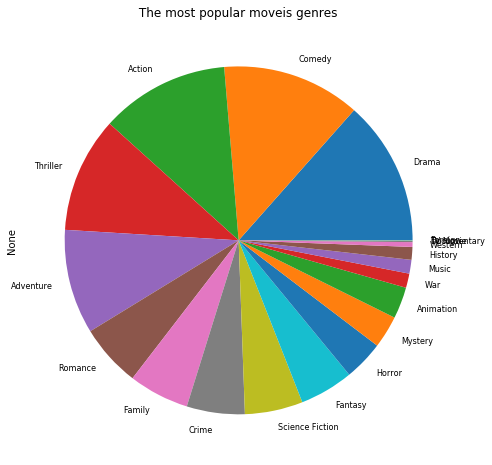

```python
count.plot(kind='pie', figsize = (10, 8),fontsize=8)
ax = plt.gca()
ax.set_title(" The most popular moveis genres ",fontsize=12);
```

The most popular moveis genres is drama

### Research Question 2 (What kinds of properties are associated withmovies that have high revenues?)

```python
moveis_rev = df.groupby(['the_actor'])['revenue_adj'].sum() / df.groupby(['the_actor'])['revenue_adj'].count()
moveis_rev = moveis_rev.nlargest(n = 10)
```

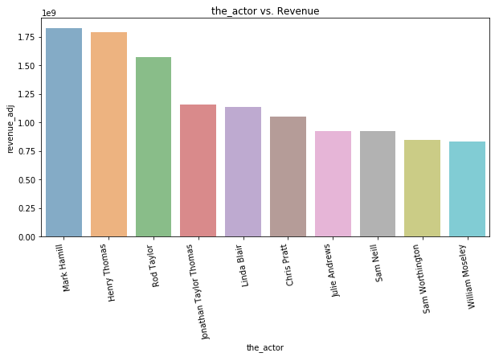

```python
plt.subplots(figsize = (10,5))
plt.xticks(rotation=100)
ax = sns.barplot(moveis_rev.index,moveis_rev.tolist(), alpha = 0.6)
ax.set_title('the_actor vs. Revenue',fontsize=12)
ax.set_ylabel('revenue_adj');
```

main actors contribute to higher revenue

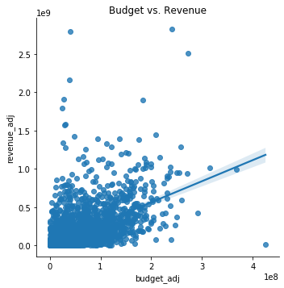

```python
sns.lmplot(x='budget_adj', y='revenue_adj', data=df)
ax = plt.gca()
ax.set_title("Budget vs. Revenue",fontsize=12);
```

most high budgets associated with high revenue

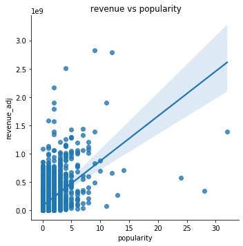

```python
sns.lmplot(x = 'popularity', y = 'revenue_adj', data = df)
ax = plt.gca()
ax.set_title(" revenue vs popularity",fontsize=12);
```

most high popularity associated with high revenue

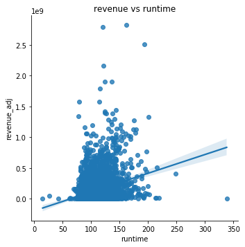

```python
sns.lmplot(x='runtime', y='revenue_adj', data=df)
ax = plt.gca()
ax.set_title("revenue vs runtime",fontsize=12);
```

## limitations:

the budget and revenue column does not have a currency unit but it is possible that each movie have a different budget in different currency according to which country the movie is produced in even though dropping the rows with missing values also has affected the overall analysis and some columns contain multi value